# Risk Factor Analysis

## Outcome Variable

**Outcome Variable:** wast_rec90d

## Predictor Variables

**Intervention Variable:** predfeed3

**Adjustment Set:**

- arm
- sex
- month
- brthmon
- W_mage
- meducyrs
- feducyrs
- hhwealth_quart
- hfoodsec
- W_mhtcm
- vagbrth
- W_gagebrth
- W_birthwt
- W_birthlen
- W_nrooms
- W_nchldlt5
- W_parity
- impfloor
- impsan
- safeh20
- delta_W_mage
- delta_meducyrs
- delta_feducyrs
- delta_hhwealth_quart
- delta_hfoodsec
- delta_W_mhtcm
- delta_vagbrth
- delta_W_gagebrth
- delta_W_birthwt
- delta_W_birthlen
- delta_W_nrooms
- delta_W_nchldlt5
- delta_W_parity
- delta_impfloor
- delta_impsan
- delta_safeh20

## Stratifying Variables

The analysis was stratified on these variable(s):

- agecat
- studyid
- country

## Data Summary

| agecat | studyid | country | predfeed3 | wast_rec90d | n_cell | n |
| --- | --- | --- | --- | --- | --- | --- |
| 0-24 months | ki0047075b-MAL-ED | BANGLADESH | 1 | 0 | 37 | 118 |
| 0-24 months | ki0047075b-MAL-ED | BANGLADESH | 1 | 1 | 70 | 118 |
| 0-24 months | ki0047075b-MAL-ED | BANGLADESH | 0 | 0 | 5 | 118 |
| 0-24 months | ki0047075b-MAL-ED | BANGLADESH | 0 | 1 | 6 | 118 |
| 0-24 months | ki0047075b-MAL-ED | BRAZIL | 1 | 0 | 4 | 23 |
| 0-24 months | ki0047075b-MAL-ED | BRAZIL | 1 | 1 | 10 | 23 |
| 0-24 months | ki0047075b-MAL-ED | BRAZIL | 0 | 0 | 2 | 23 |
| 0-24 months | ki0047075b-MAL-ED | BRAZIL | 0 | 1 | 7 | 23 |
| 0-24 months | ki0047075b-MAL-ED | INDIA | 1 | 0 | 48 | 177 |
| 0-24 months | ki0047075b-MAL-ED | INDIA | 1 | 1 | 76 | 177 |
| 0-24 months | ki0047075b-MAL-ED | INDIA | 0 | 0 | 22 | 177 |
| 0-24 months | ki0047075b-MAL-ED | INDIA | 0 | 1 | 31 | 177 |
| 0-24 months | ki0047075b-MAL-ED | NEPAL | 1 | 0 | 15 | 92 |
| 0-24 months | ki0047075b-MAL-ED | NEPAL | 1 | 1 | 38 | 92 |
| 0-24 months | ki0047075b-MAL-ED | NEPAL | 0 | 0 | 5 | 92 |
| 0-24 months | ki0047075b-MAL-ED | NEPAL | 0 | 1 | 34 | 92 |
| 0-24 months | ki0047075b-MAL-ED | PERU | 1 | 0 | 5 | 32 |
| 0-24 months | ki0047075b-MAL-ED | PERU | 1 | 1 | 14 | 32 |
| 0-24 months | ki0047075b-MAL-ED | PERU | 0 | 0 | 1 | 32 |
| 0-24 months | ki0047075b-MAL-ED | PERU | 0 | 1 | 12 | 32 |
| 0-24 months | ki0047075b-MAL-ED | SOUTH AFRICA | 1 | 0 | 6 | 78 |
| 0-24 months | ki0047075b-MAL-ED | SOUTH AFRICA | 1 | 1 | 18 | 78 |
| 0-24 months | ki0047075b-MAL-ED | SOUTH AFRICA | 0 | 0 | 7 | 78 |
| 0-24 months | ki0047075b-MAL-ED | SOUTH AFRICA | 0 | 1 | 47 | 78 |
| 0-24 months | ki0047075b-MAL-ED | TANZANIA, UNITED REPUBLIC OF | 1 | 0 | 1 | 45 |
| 0-24 months | ki0047075b-MAL-ED | TANZANIA, UNITED REPUBLIC OF | 1 | 1 | 13 | 45 |
| 0-24 months | ki0047075b-MAL-ED | TANZANIA, UNITED REPUBLIC OF | 0 | 0 | 7 | 45 |
| 0-24 months | ki0047075b-MAL-ED | TANZANIA, UNITED REPUBLIC OF | 0 | 1 | 24 | 45 |
| 0-24 months | ki1000109-EE | PAKISTAN | 1 | 0 | 131 | 257 |
| 0-24 months | ki1000109-EE | PAKISTAN | 1 | 1 | 104 | 257 |

[output cut: 102 more lines]

The following strata were considered:

- agecat: 0-24 months, studyid: ki0047075b-MAL-ED, country: BANGLADESH
- agecat: 0-24 months, studyid: ki0047075b-MAL-ED, country: BRAZIL
- agecat: 0-24 months, studyid: ki0047075b-MAL-ED, country: INDIA
- agecat: 0-24 months, studyid: ki0047075b-MAL-ED, country: NEPAL
- agecat: 0-24 months, studyid: ki0047075b-MAL-ED, country: PERU
- agecat: 0-24 months, studyid: ki0047075b-MAL-ED, country: SOUTH AFRICA
- agecat: 0-24 months, studyid: ki0047075b-MAL-ED, country: TANZANIA, UNITED REPUBLIC OF
- agecat: 0-24 months, studyid: ki1000109-EE, country: PAKISTAN
- agecat: 0-24 months, studyid: ki1113344-GMS-Nepal, country: NEPAL
- agecat: 0-24 months, studyid: kiGH5241-JiVitA-3, country: BANGLADESH
- agecat: 0-24 months, studyid: kiGH5241-JiVitA-4, country: BANGLADESH
- agecat: 0-6 months, studyid: ki0047075b-MAL-ED, country: BANGLADESH
- agecat: 0-6 months, studyid: ki0047075b-MAL-ED, country: BRAZIL
- agecat: 0-6 months, studyid: ki0047075b-MAL-ED, country: INDIA
- agecat: 0-6 months, studyid: ki0047075b-MAL-ED, country: NEPAL
- agecat: 0-6 months, studyid: ki0047075b-MAL-ED, country: PERU
- agecat: 0-6 months, studyid: ki0047075b-MAL-ED, country: SOUTH AFRICA
- agecat: 0-6 months, studyid: ki0047075b-MAL-ED, country: TANZANIA, UNITED REPUBLIC OF
- agecat: 0-6 months, studyid: ki1000109-EE, country: PAKISTAN
- agecat: 0-6 months, studyid: ki1113344-GMS-Nepal, country: NEPAL
- agecat: 0-6 months, studyid: kiGH5241-JiVitA-3, country: BANGLADESH
- agecat: 0-6 months, studyid: kiGH5241-JiVitA-4, country: BANGLADESH
- agecat: 6-24 months, studyid: ki0047075b-MAL-ED, country: BANGLADESH
- agecat: 6-24 months, studyid: ki0047075b-MAL-ED, country: BRAZIL
- agecat: 6-24 months, studyid: ki0047075b-MAL-ED, country: INDIA
- agecat: 6-24 months, studyid: ki0047075b-MAL-ED, country: NEPAL
- agecat: 6-24 months, studyid: ki0047075b-MAL-ED, country: PERU
- agecat: 6-24 months, studyid: ki0047075b-MAL-ED, country: SOUTH AFRICA
- agecat: 6-24 months, studyid: ki0047075b-MAL-ED, country: TANZANIA, UNITED REPUBLIC OF
- agecat: 6-24 months, studyid: ki1000109-EE, country: PAKISTAN
- agecat: 6-24 months, studyid: ki1113344-GMS-Nepal, country: NEPAL
- agecat: 6-24 months, studyid: kiGH5241-JiVitA-3, country: BANGLADESH
- agecat: 6-24 months, studyid: kiGH5241-JiVitA-4, country: BANGLADESH

### Dropped Strata

Some strata were dropped due to rare outcomes:

- agecat: 0-24 months, studyid: ki0047075b-MAL-ED, country: BRAZIL
- agecat: 0-24 months, studyid: ki0047075b-MAL-ED, country: PERU
- agecat: 0-24 months, studyid: ki0047075b-MAL-ED, country: TANZANIA, UNITED REPUBLIC OF
- agecat: 0-24 months, studyid: ki1000109-EE, country: PAKISTAN
- agecat: 0-24 months, studyid: kiGH5241-JiVitA-4, country: BANGLADESH
- agecat: 0-6 months, studyid: ki0047075b-MAL-ED, country: BANGLADESH
- agecat: 0-6 months, studyid: ki0047075b-MAL-ED, country: BRAZIL
- agecat: 0-6 months, studyid: ki0047075b-MAL-ED, country: NEPAL
- agecat: 0-6 months, studyid: ki0047075b-MAL-ED, country: PERU
- agecat: 0-6 months, studyid: ki0047075b-MAL-ED, country: SOUTH AFRICA
- agecat: 0-6 months, studyid: ki0047075b-MAL-ED, country: TANZANIA, UNITED REPUBLIC OF
- agecat: 0-6 months, studyid: ki1000109-EE, country: PAKISTAN
- agecat: 0-6 months, studyid: kiGH5241-JiVitA-4, country: BANGLADESH
- agecat: 6-24 months, studyid: ki0047075b-MAL-ED, country: BANGLADESH
- agecat: 6-24 months, studyid: ki0047075b-MAL-ED, country: BRAZIL
- agecat: 6-24 months, studyid: ki0047075b-MAL-ED, country: NEPAL
- agecat: 6-24 months, studyid: ki0047075b-MAL-ED, country: PERU
- agecat: 6-24 months, studyid: ki0047075b-MAL-ED, country: SOUTH AFRICA
- agecat: 6-24 months, studyid: ki0047075b-MAL-ED, country: TANZANIA, UNITED REPUBLIC OF
- agecat: 6-24 months, studyid: ki1000109-EE, country: PAKISTAN
- agecat: 6-24 months, studyid: kiGH5241-JiVitA-3, country: BANGLADESH
- agecat: 6-24 months, studyid: kiGH5241-JiVitA-4, country: BANGLADESH

## Methods Detail

We’re interested in the causal parameters $E[Y_a]$ for all values of $a \in \mathcal{A}$. These parameters represent the mean outcome if, possibly contrary to fact, we intervened to set all units to have $A=a$. Under the randomization and positivity assumptions, these are identified by the statistical parameters $\psi_a=E_W[E_{Y|A,W}(Y|A=a,W)]$. In addition, we’re interested in the mean of $Y$, $E[Y]$ under no intervention (the observed mean). We will estimate these parameters by using SuperLearner to fit the relevant likelihood factors – $E_{Y|A,W}(Y|A=a,W)$ and $p(A=a|W)$, and then updating our likelihood fit using a joint TMLE.

For unadjusted analyses ($W=\{\}$), initial likelihoods were estimated using Lrnr_glm to estimate the simple $E(Y|A)$ and Lrnr_mean to estimate $p(A)$. For adjusted analyses, a small library containing Lrnr_glmnet, Lrnr_xgboost, and Lrnr_mean was used.

Having estimated these parameters, we will then use the delta method to estimate relative risks and attributable risks relative to a prespecified baseline level of $A$.

# Results Detail

## Results Plots

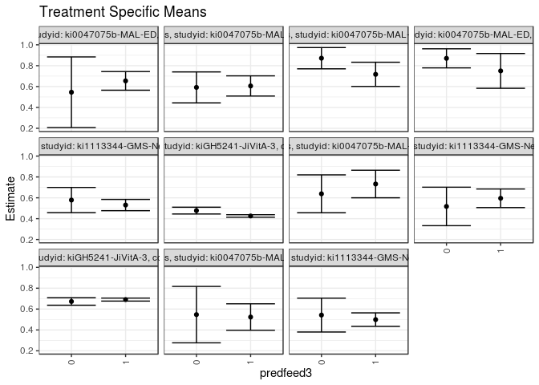

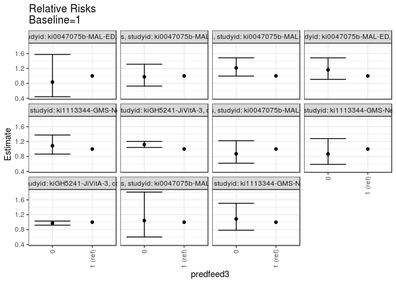

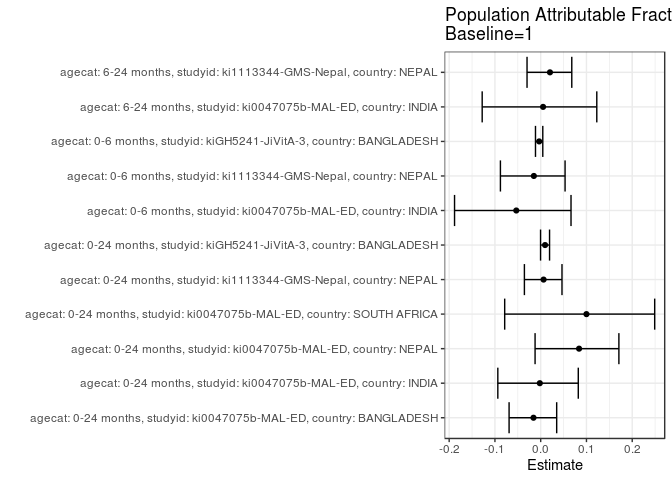

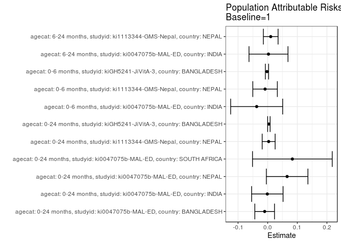

## Results Table

### Parameter: TSM

| agecat | studyid | country | intervention_level | baseline_level | estimate | ci_lower | ci_upper |
| --- | --- | --- | --- | --- | --- | --- | --- |
| 0-24 months | ki0047075b-MAL-ED | BANGLADESH | 1 | NA | 0.6542056 | 0.5647903 | 0.7436209 |
| 0-24 months | ki0047075b-MAL-ED | BANGLADESH | 0 | NA | 0.5454545 | 0.2068166 | 0.8840925 |
| 0-24 months | ki0047075b-MAL-ED | INDIA | 1 | NA | 0.6056860 | 0.5089235 | 0.7024484 |
| 0-24 months | ki0047075b-MAL-ED | INDIA | 0 | NA | 0.5917497 | 0.4433798 | 0.7401196 |
| 0-24 months | ki0047075b-MAL-ED | NEPAL | 1 | NA | 0.7169811 | 0.6011080 | 0.8328543 |
| 0-24 months | ki0047075b-MAL-ED | NEPAL | 0 | NA | 0.8717949 | 0.7698881 | 0.9737017 |
| 0-24 months | ki0047075b-MAL-ED | SOUTH AFRICA | 1 | NA | 0.7500000 | 0.5833892 | 0.9166108 |
| 0-24 months | ki0047075b-MAL-ED | SOUTH AFRICA | 0 | NA | 0.8703704 | 0.7788517 | 0.9618891 |
| 0-24 months | ki1113344-GMS-Nepal | NEPAL | 1 | NA | 0.5306756 | 0.4766810 | 0.5846701 |
| 0-24 months | ki1113344-GMS-Nepal | NEPAL | 0 | NA | 0.5785567 | 0.4576423 | 0.6994710 |
| 0-24 months | kiGH5241-JiVitA-3 | BANGLADESH | 1 | NA | 0.4257599 | 0.4137664 | 0.4377533 |
| 0-24 months | kiGH5241-JiVitA-3 | BANGLADESH | 0 | NA | 0.4773652 | 0.4447701 | 0.5099603 |
| 0-6 months | ki0047075b-MAL-ED | INDIA | 1 | NA | 0.7322036 | 0.6000452 | 0.8643621 |
| 0-6 months | ki0047075b-MAL-ED | INDIA | 0 | NA | 0.6383592 | 0.4566649 | 0.8200534 |
| 0-6 months | ki1113344-GMS-Nepal | NEPAL | 1 | NA | 0.5954257 | 0.5063264 | 0.6845250 |
| 0-6 months | ki1113344-GMS-Nepal | NEPAL | 0 | NA | 0.5172372 | 0.3327011 | 0.7017732 |
| 0-6 months | kiGH5241-JiVitA-3 | BANGLADESH | 1 | NA | 0.6909723 | 0.6765933 | 0.7053512 |
| 0-6 months | kiGH5241-JiVitA-3 | BANGLADESH | 0 | NA | 0.6728280 | 0.6369088 | 0.7087471 |
| 6-24 months | ki0047075b-MAL-ED | INDIA | 1 | NA | 0.5235761 | 0.3967752 | 0.6503769 |
| 6-24 months | ki0047075b-MAL-ED | INDIA | 0 | NA | 0.5467828 | 0.2763161 | 0.8172494 |
| 6-24 months | ki1113344-GMS-Nepal | NEPAL | 1 | NA | 0.4990603 | 0.4344927 | 0.5636279 |
| 6-24 months | ki1113344-GMS-Nepal | NEPAL | 0 | NA | 0.5425272 | 0.3801013 | 0.7049531 |

### Parameter: E(Y)

| agecat | studyid | country | intervention_level | baseline_level | estimate | ci_lower | ci_upper |
| --- | --- | --- | --- | --- | --- | --- | --- |
| 0-24 months | ki0047075b-MAL-ED | BANGLADESH | NA | NA | 0.6440678 | 0.5565826 | 0.7315530 |
| 0-24 months | ki0047075b-MAL-ED | INDIA | NA | NA | 0.6045198 | 0.5246128 | 0.6844268 |
| 0-24 months | ki0047075b-MAL-ED | NEPAL | NA | NA | 0.7826087 | 0.7016344 | 0.8635829 |
| 0-24 months | ki0047075b-MAL-ED | SOUTH AFRICA | NA | NA | 0.8333333 | 0.7515924 | 0.9150742 |
| 0-24 months | ki1113344-GMS-Nepal | NEPAL | NA | NA | 0.5340426 | 0.4848509 | 0.5832342 |
| 0-24 months | kiGH5241-JiVitA-3 | BANGLADESH | NA | NA | 0.4298760 | 0.4185519 | 0.4412000 |
| 0-6 months | ki0047075b-MAL-ED | INDIA | NA | NA | 0.6951220 | 0.5922224 | 0.7980215 |
| 0-6 months | ki1113344-GMS-Nepal | NEPAL | NA | NA | 0.5866667 | 0.5072781 | 0.6660552 |
| 0-6 months | kiGH5241-JiVitA-3 | BANGLADESH | NA | NA | 0.6886463 | 0.6752359 | 0.7020567 |
| 6-24 months | ki0047075b-MAL-ED | INDIA | NA | NA | 0.5263158 | 0.4116286 | 0.6410029 |
| 6-24 months | ki1113344-GMS-Nepal | NEPAL | NA | NA | 0.5093750 | 0.4496016 | 0.5691484 |

### Parameter: RR

| agecat | studyid | country | intervention_level | baseline_level | estimate | ci_lower | ci_upper |
| --- | --- | --- | --- | --- | --- | --- | --- |
| 0-24 months | ki0047075b-MAL-ED | BANGLADESH | 1 | 1 | 1.0000000 | 1.0000000 | 1.000000 |
| 0-24 months | ki0047075b-MAL-ED | BANGLADESH | 0 | 1 | 0.8337662 | 0.4414864 | 1.574604 |
| 0-24 months | ki0047075b-MAL-ED | INDIA | 1 | 1 | 1.0000000 | 1.0000000 | 1.000000 |
| 0-24 months | ki0047075b-MAL-ED | INDIA | 0 | 1 | 0.9769910 | 0.7262833 | 1.314241 |
| 0-24 months | ki0047075b-MAL-ED | NEPAL | 1 | 1 | 1.0000000 | 1.0000000 | 1.000000 |
| 0-24 months | ki0047075b-MAL-ED | NEPAL | 0 | 1 | 1.2159244 | 0.9954839 | 1.485179 |
| 0-24 months | ki0047075b-MAL-ED | SOUTH AFRICA | 1 | 1 | 1.0000000 | 1.0000000 | 1.000000 |
| 0-24 months | ki0047075b-MAL-ED | SOUTH AFRICA | 0 | 1 | 1.1604938 | 0.9073673 | 1.484235 |
| 0-24 months | ki1113344-GMS-Nepal | NEPAL | 1 | 1 | 1.0000000 | 1.0000000 | 1.000000 |
| 0-24 months | ki1113344-GMS-Nepal | NEPAL | 0 | 1 | 1.0902267 | 0.8638066 | 1.375996 |
| 0-24 months | kiGH5241-JiVitA-3 | BANGLADESH | 1 | 1 | 1.0000000 | 1.0000000 | 1.000000 |
| 0-24 months | kiGH5241-JiVitA-3 | BANGLADESH | 0 | 1 | 1.1212075 | 1.0429857 | 1.205296 |
| 0-6 months | ki0047075b-MAL-ED | INDIA | 1 | 1 | 1.0000000 | 1.0000000 | 1.000000 |
| 0-6 months | ki0047075b-MAL-ED | INDIA | 0 | 1 | 0.8718328 | 0.6208256 | 1.224325 |
| 0-6 months | ki1113344-GMS-Nepal | NEPAL | 1 | 1 | 1.0000000 | 1.0000000 | 1.000000 |
| 0-6 months | ki1113344-GMS-Nepal | NEPAL | 0 | 1 | 0.8686847 | 0.5893599 | 1.280394 |
| 0-6 months | kiGH5241-JiVitA-3 | BANGLADESH | 1 | 1 | 1.0000000 | 1.0000000 | 1.000000 |
| 0-6 months | kiGH5241-JiVitA-3 | BANGLADESH | 0 | 1 | 0.9737409 | 0.9201460 | 1.030458 |
| 6-24 months | ki0047075b-MAL-ED | INDIA | 1 | 1 | 1.0000000 | 1.0000000 | 1.000000 |
| 6-24 months | ki0047075b-MAL-ED | INDIA | 0 | 1 | 1.0443234 | 0.6029232 | 1.808873 |
| 6-24 months | ki1113344-GMS-Nepal | NEPAL | 1 | 1 | 1.0000000 | 1.0000000 | 1.000000 |
| 6-24 months | ki1113344-GMS-Nepal | NEPAL | 0 | 1 | 1.0870974 | 0.7839125 | 1.507542 |

### Parameter: PAR

| agecat | studyid | country | intervention_level | baseline_level | estimate | ci_lower | ci_upper |
| --- | --- | --- | --- | --- | --- | --- | --- |
| 0-24 months | ki0047075b-MAL-ED | BANGLADESH | 1 | NA | -0.0101378 | -0.0434045 | 0.0231289 |
| 0-24 months | ki0047075b-MAL-ED | INDIA | 1 | NA | -0.0011662 | -0.0542463 | 0.0519140 |
| 0-24 months | ki0047075b-MAL-ED | NEPAL | 1 | NA | 0.0656276 | -0.0044345 | 0.1356896 |
| 0-24 months | ki0047075b-MAL-ED | SOUTH AFRICA | 1 | NA | 0.0833333 | -0.0511360 | 0.2178027 |
| 0-24 months | ki1113344-GMS-Nepal | NEPAL | 1 | NA | 0.0033670 | -0.0185552 | 0.0252892 |
| 0-24 months | kiGH5241-JiVitA-3 | BANGLADESH | 1 | NA | 0.0041161 | -0.0001110 | 0.0083432 |
| 0-6 months | ki0047075b-MAL-ED | INDIA | 1 | NA | -0.0370817 | -0.1249011 | 0.0507377 |
| 0-6 months | ki1113344-GMS-Nepal | NEPAL | 1 | NA | -0.0087590 | -0.0501366 | 0.0326186 |
| 0-6 months | kiGH5241-JiVitA-3 | BANGLADESH | 1 | NA | -0.0023260 | -0.0078176 | 0.0031656 |
| 6-24 months | ki0047075b-MAL-ED | INDIA | 1 | NA | 0.0027397 | -0.0630431 | 0.0685225 |
| 6-24 months | ki1113344-GMS-Nepal | NEPAL | 1 | NA | 0.0103147 | -0.0145536 | 0.0351830 |

### Parameter: PAF

| agecat | studyid | country | intervention_level | baseline_level | estimate | ci_lower | ci_upper |
| --- | --- | --- | --- | --- | --- | --- | --- |
| 0-24 months | ki0047075b-MAL-ED | BANGLADESH | 1 | NA | -0.0157403 | -0.0690683 | 0.0349276 |
| 0-24 months | ki0047075b-MAL-ED | INDIA | 1 | NA | -0.0019291 | -0.0936921 | 0.0821348 |
| 0-24 months | ki0047075b-MAL-ED | NEPAL | 1 | NA | 0.0838574 | -0.0122835 | 0.1708674 |
| 0-24 months | ki0047075b-MAL-ED | SOUTH AFRICA | 1 | NA | 0.1000000 | -0.0786812 | 0.2490831 |
| 0-24 months | ki1113344-GMS-Nepal | NEPAL | 1 | NA | 0.0063047 | -0.0356129 | 0.0465257 |
| 0-24 months | kiGH5241-JiVitA-3 | BANGLADESH | 1 | NA | 0.0095751 | -0.0003044 | 0.0193569 |
| 0-6 months | ki0047075b-MAL-ED | INDIA | 1 | NA | -0.0533456 | -0.1882588 | 0.0662498 |
| 0-6 months | ki1113344-GMS-Nepal | NEPAL | 1 | NA | -0.0149301 | -0.0880246 | 0.0532538 |
| 0-6 months | kiGH5241-JiVitA-3 | BANGLADESH | 1 | NA | -0.0033776 | -0.0113856 | 0.0045670 |
| 6-24 months | ki0047075b-MAL-ED | INDIA | 1 | NA | 0.0052054 | -0.1278594 | 0.1225713 |
| 6-24 months | ki1113344-GMS-Nepal | NEPAL | 1 | NA | 0.0202497 | -0.0298504 | 0.0679125 |